# MG205: Econometrics Theory and Applications

Topic 2: Linear Regression Model

José Ignacio González-Rojas

j.i.gonzalez-rojas@lse.ac.uk

London School of Economics and Political Science

## What You’ll Master Today

### Core Skills for Econometric Proofs

#### Mathematical Skills

- How to structure a proof
- Moving from “given” to “show”
- Recognising when steps are valid
- Connecting algebra to concepts

#### Econometric Concepts

- Population vs. sample distinction
- Correlation and regression connection
- Errors vs. residuals difference
- OLS derivation from scratch

We’ll go slowly - every step will be justified

## Population Model vs. Sample Regression

### These Are Different Worlds!

#### The Population (Unknown Truth)

$$y_{i} = \beta_{0} + \beta_{1} x_{i} + e_{i}$$

- **Fixed Values**: $\beta_0, \beta_1, e_i$
- **Parameters of interest:** $\beta_0, \beta_1$
- **Error**: $e_{i}$
- **Operators**: $\text{cov}(x,y)$, $\text{var}(x)$, $\mathbb{E}[\cdot]$

#### Our Sample (What We Observe and Estimate from the Data)

$$y_{i} = \hat{\beta}_0 + \hat{\beta}_1 x_{i} + \hat{\varepsilon}_{i}$$

- **Estimates**: $\hat{\beta}_{0}, \hat{\beta}_{1}$
- **Residual**: $\hat{\varepsilon}_{i}$
- **Operators**: $\widehat{\text{cov}}(x,y)$, $\widehat{\text{var}}(x)$, $\bar{x}$

# **Exercise 1:** Correlation and Slope

## If Correlation is Negative, Slope Must Be Too

### Understanding What We’re Asked to Prove

#### Mathematical Statement

If $\rho(y,x) < 0$, then $\beta_{1} < 0$

#### What This Means

- **Given**: We know correlation is negative
- **We Need To Show**: This forces slope to be negative
- **Strategy**: Show both have the same sign determinant

## Both Formulas Share a Critical Component

### The Key to Our Proof

#### Correlation Formula

$$\rho(x,y) =
\frac{
\color{#EE7733}{\text{cov}(x,y)}
}{
\sqrt{\color{#0077BB}{\text{var}(x)}} \cdot \sqrt{\text{var}(y)}
}$$

#### OLS Slope Formula

$$\beta_{1} =
\frac{
\color{#EE7733}{\text{cov}(x,y)}
}{
\color{#0077BB}{\text{var}(x)}
}$$

Both have $\color{#EE7733}{\text{cov}(x,y)}$ in the numerator

## The Sign Depends Only on Covariance

### Analysing the Sign of the Correlation $\rho(x,y)$

$$\rho(x,y) = \frac{\text{cov}(x,y)}{\underbrace{\sqrt{\text{var}(x)}}_{+} \cdot \underbrace{\sqrt{\text{var}(y)}}_{+}}$$

- $\therefore\text{sign}(\rho(x,y)) = \text{sign}(\text{cov}(x,y))$

### Analysing the Sign of the Slope $\beta_1$

$$\beta_1 = \frac{\text{cov}(x,y)}{\underbrace{\text{var}(x)}_{+}}$$

- $\therefore\text{sign}(\beta_1) = \text{sign}(\text{cov}(x,y))$

Both correlation and slope depend only on the sign of covariance ✓

If $\rho(x,y) < 0$, then $\text{cov}(x,y) < 0$, and thus $\beta_1 < 0$.$\blacksquare$

# **Exercise 2:** Errors vs Residuals

## Residuals Always Sum to Zero, Errors Almost Never Do

### Mechanical Properties Are Not Statistical Properties

#### The Statement to Evaluate

“While the error terms ($e_{i}$) and the OLS residuals ($\hat{\varepsilon}_{i}$) are clearly not the same thing, it is always the case that”
$$\sum_{i=1}^{n} e_{i} = \sum_{i=1}^{n} \hat{\varepsilon}_{i} = 0$$

#### Breaking It Into Two Claims

1. Errors sum to zero: $\sum_{i} e_{i} = 0$
2. Residuals sum to zero: $\sum_{i} \hat{\varepsilon}_{i} = 0$

## Only One Part is True

### Mechanical Property vs Random Realization

#### 1. Errors: ✗ FALSE - Almost Never!

- Yes, $\mathbb{E}[e_{i}] = 0$ (Assumption 4)
- But actual sum is random
- Think about flipping a fair coin $n$ times
- $\sum_{i=1}^{n} e_{i} \neq \sum_{i=1}^{n} \mathbb{E}[e_{i}]$

#### 2. Residuals: ✓ TRUE - Always!

- This is Mechanical Property 1 (MP1)
  - True by construction from FOC
  - Observable and verifiable

Since one part is FALSE, the entire claim is **FALSE** ✗

# **Exercise 3:** Visual Interpretation

## Statistical Patterns Cannot Definitively Disprove Theories

### Unlikely Is Not Impossible

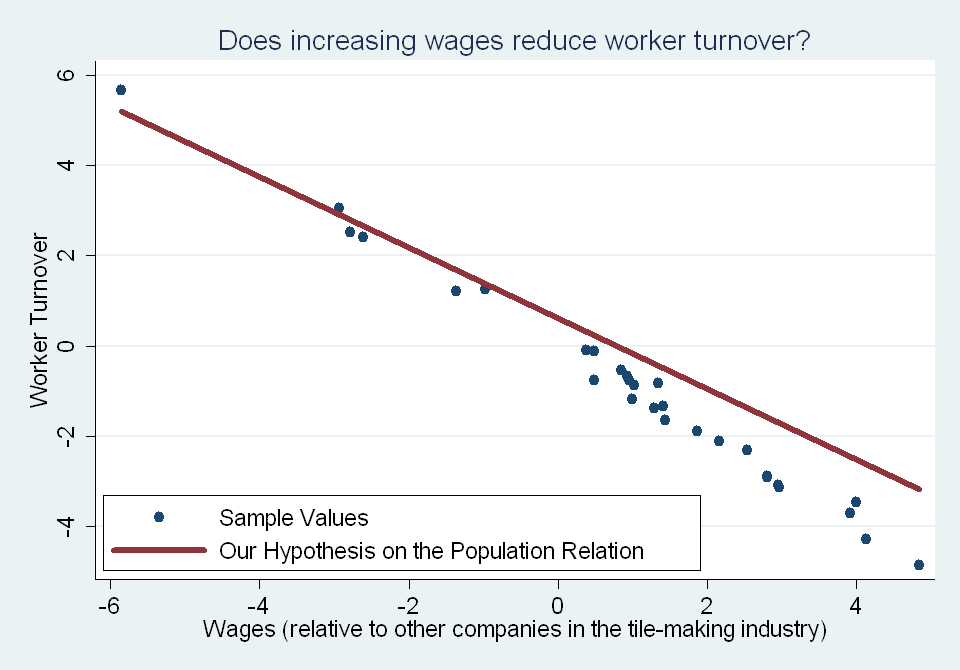

Hypothesised relationship

#### Does these data prove our hypothesis (red line) wrong?

1. Yes, categorically proves it wrong
2. **Suggests wrong but doesn’t prove**

#### Why?

- Pattern is **unlikely** if hypothesis true
- But not **impossible** - could be unlucky draws
- Statistics deals with probabilities, not certainties

## Mathematical Violations Provide Certainty

### When Mechanical Properties Are Violated

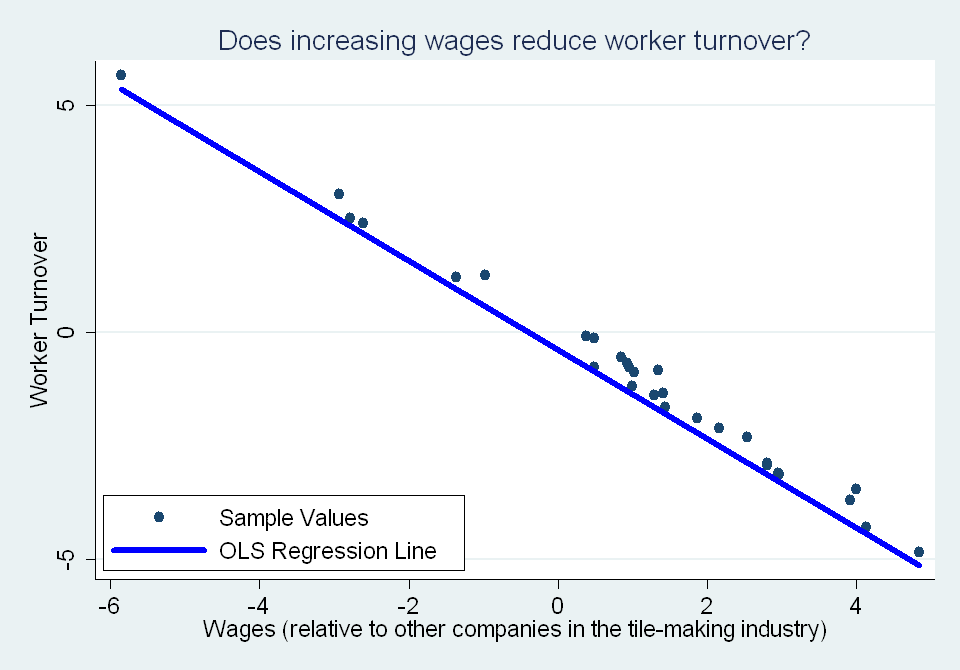

Trainee’s regression

#### All points lie above the proposed OLS estimated line

- $\therefore$ Every residual is positive

#### Has the trainee made a mistake?

1. **Definitely made a mistake!**
2. Probably made a mistake

#### Why We’re Certain

- MP1 requires: $\sum_{i} \hat{\varepsilon}_{i} = 0$
- Here: All $\hat{\varepsilon}_{i} > 0$ ❌

# **Exercise 4:** Deriving Ordinary Least Squares (OLS) estimator

## OLS Minimises Sum of Squared Residuals

### The Fundamental Estimation Problem

#### Choose $b_{0}$ and $b_{1}$ to minimise

$$S(b_{0}, b_{1}) = \sum_{i=1}^n (y_{i} - b_{0} - b_{1}x_{i})^2$$

#### Minimisation via Calculus

1. Take partial derivatives: $\frac{\partial S}{\partial b_{0}}$ and $\frac{\partial S}{\partial b_{1}}$
2. Set both equal to zero (FOCs)
3. Solve the resulting system

We use $b_{0}, b_{1}$ during minimisation, then denote the solution as $\hat{\beta}_{0}, \hat{\beta}_{1}$

## Partial Derivative with Respect to Intercept

### Chain Rule Yields First Order Condition

#### Start with $S(b_{0}, b_{1}) = \sum_{i=1}^n (y_{i} - b_{0} - b_{1}x_{i})^2$

#### Use chain rule

$$\frac{\partial S}{\partial b_{0}} \equiv \frac{\partial}{\partial b_{0}}\sum_{i=1}^n(y_{i} - b_{0} - b_{1}x_{i})^2$$

#### Apply chain rule again

$$= \sum_{i=1}^n 2(y_{i} - b_{0} - b_{1}x_{i}) \cdot \frac{\partial}{\partial b_{0}}(y_{i} - b_{0} - b_{1}x_{i})$$

#### Compute the Inner derivative

$$= \sum_{i=1}^n 2(y_{i} - b_{0} - b_{1}x_{i}) \cdot (-1)$$

#### Result

$$\frac{\partial S}{\partial b_{0}} = -2\sum_{i=1}^{n}(y_{i} - b_{0} - b_{1}x_{i})$$

## Partial Derivative with Respect to Slope

### Note How $x_i$ Enters the Derivative

#### Start with $S(b_{0}, b_{1}) = \sum_{i=1}^{n}(y_{i} - b_{0} - b_{1}x_{i})^{2}$

#### Use chain rule

$$\frac{\partial S}{\partial b_{1}} \equiv \frac{\partial}{\partial b_{1}}\sum_{i=1}^{n}(y_{i} - b_{0} - b_{1}x_{i})^{2}$$

#### Apply chain rule again

$$= \sum_{i=1}^{n} 2(y_{i} - b_{0} - b_{1}x_{i}) \cdot \frac{\partial}{\partial b_{1}}(y_{i} - b_{0} - b_{1}x_{i})$$

#### Take the Inner derivative (note the $x_{i}$!)

$$= \sum_{i=1}^{n} 2(y_{i} - b_{0} - b_{1}x_{i}) \cdot (-x_{i})$$

#### Result

$$\frac{\partial S}{\partial b_{1}} = -2\sum_{i=1}^{n} x_{i}(y_{i} - b_{0} - b_{1}x_{i})$$

## First Order Conditions Yield Mechanical Properties

### From Calculus to Econometrics

|  | FOC 1 (w.r.t. $b_0$) | FOC 2 (w.r.t. $b_1$) |
| --- | --- | --- |
| **Derivative** | $\frac{\partial S}{\partial b_{0}} = -2\sum_{i}(y_{i} - b_{0} - b_{1}x_{i})$ | $\frac{\partial S}{\partial b_{1}} = -2\sum_{i} x_{i}(y_{i} - b_{0} - b_{1}x_{i})$ |
| **Set = 0** | $\sum_{i}(y_{i} - \hat{\beta}_{0} - \hat{\beta}_{1}x_{i}) = 0$ | $\sum_{i}x_{i}(y_{i} - \hat{\beta}_{0} - \hat{\beta}_{1}x_{i}) = 0$ |
| **Using** $\hat{\varepsilon}_{i}$ | $\sum_{i}\hat{\varepsilon}_{i} = 0$ (MP1) | $\sum_{i}x_{i}\hat{\varepsilon}_{i} = 0$ (MP2) |

The $\hat{\beta}$ are THE values that minimize the sum of squares

## Finding the Intercept Formula

### Solving FOC 1 for $\hat{\beta}_0$

#### Start with FOC 1: $\sum_{i=1}^n(y_i - \hat{\beta}_0 - \hat{\beta}_1x_i) = 0$

#### Separate the sums

$$\sum_{i=1}^{n} y_{i} - \sum_{i=1}^{n} \hat{\beta}_{0} - \sum_{i=1}^{n} \hat{\beta}_{1}x_{i} = 0$$

#### Take constants out of sums

$$\sum_{i=1}^{n} y_i - n\hat{\beta}_{0} - \hat{\beta}_{1}\sum_{i=1}^{n} x_{i} = 0$$

#### Multiply by $1 (\frac{n}{n})$

$$n\bar{y} - n\hat{\beta}_{0} - n\hat{\beta}_{1}\bar{x} = 0$$

#### Divide by $n$ and solve

$$\boxed{\hat{\beta}_{0} = \bar{y} - \hat{\beta}_{1}\bar{x}\quad \tag{MP3}}$$

## Starting to Solve for $\hat{\beta}_{1}$

### Using FOC 2 with Our Result

#### Start with FOC 2: $\sum_{i=1}^{n} x_{i}(y_{i} - \hat{\beta}_{0} - \hat{\beta}_{1}x_{i}) = 0$

#### Substitute $\hat{\beta}_{0} = \bar{y} - \hat{\beta}_{1}\bar{x}$

$$\sum_{i=1}^{n} x_{i}(y_{i} - (\bar{y} - \hat{\beta}_{1}\bar{x}) - \hat{\beta}_{1}x_{i}) = 0$$

#### Simplify parentheses

$$\sum_{i=1}^{n} x_{i}(y_{i} - \bar{y} + \hat{\beta}_{1}\bar{x} - \hat{\beta}_{1}x_{i}) = 0$$

#### Factor out $\hat{\beta}_{1}$ terms

$$\sum_{i=1}^{n} x_{i}(y_{i} - \bar{y}) = \hat{\beta}_{1}\sum_{i=1}^{n} x_{i}(x_{i} - \bar{x})$$

#### Apply algebraic identity See proof

$$\sum_{i=1}^{n}(x_{i} - \bar{x})(y_{i} - \bar{y}) = \hat{\beta}_{1}\sum_{i=1}^{n}(x_{i} - \bar{x})^{2}$$

## Final Formula for the Slope

### Completing the Derivation of $\hat{\beta}_{1}$

#### Solve for $\hat{\beta}_{1}$

$$\boxed{\hat{\beta}_{1} = \frac{\sum_{i=1}^{n}(x_{i} - \bar{x})(y_{i} - \bar{y})}{\sum_{i=1}^{n}(x_{i} - \bar{x})^{2}}}$$

#### In covariance notation

$$\boxed{\hat{\beta}_{1} = \frac{\widehat{\text{cov}}(x,y)}{\widehat{\text{var}}(x)}}$$

# **Exercise 5:** Correlation and $R^{2}$

## Correlation with Fitted Values Equals Square Root of $R^2$

### Goodness of Fit Connects to Correlation

#### Definitions

1. **Correlation:** $\rho(y,\hat{y}) = \frac{\text{cov}(y,\hat{y})}{\sqrt{\text{var}(y)}\cdot\sqrt{\text{var}(\hat{y})}}$
2. **Decomposition:** $y_i = \hat{y}_i + \hat{\varepsilon}_i$
3. **R-squared:** $R^2 = \frac{\text{var}(\hat{y})}{\text{var}(y)}$

#### Key Properties

1. $\text{cov}(\hat{y}, \hat{\varepsilon}) = 0$ See proof
2. $\text{cov}(X + Z, Y) = \text{cov}(X, Y) + \text{cov}(Z, Y)$
3. $\text{cov}(X, X) = \text{var}(X)$

#### What We Want to Prove

$$\rho(y,\hat{y}) = \sqrt{R^2}$$

## Covariance Equals Variance of Fitted Values

### From $\text{cov}(y, \hat{y}) = \text{var}(\hat{y})$ to $\rho(y,\hat{y}) = \sqrt{R^2}$

#### Finding $\text{cov}(y, \hat{y})$

$$\begin{align*}
\text{cov}(y, \hat{y}) &= \text{cov}(\hat{y} + \hat{\varepsilon}, \hat{y}) \\
&= \text{cov}(\hat{y}, \hat{y}) + \underbrace{\text{cov}(\hat{\varepsilon}, \hat{y})}_{0} \\
&= \text{var}(\hat{y})
\end{align*}$$

$$\therefore \text{cov}(y, \hat{y}) = \text{var}(\hat{y})$$

#### Calculating the Correlation

$$\begin{align*}
\rho(y, \hat{y}) &= \frac{\text{cov}(y, \hat{y})}{\sqrt{\text{var}(y)} \cdot \sqrt{\text{var}(\hat{y})}} \\
&= \frac{\text{var}(\hat{y})}{\sqrt{\text{var}(y)} \cdot \sqrt{\text{var}(\hat{y})}} \\
&= \frac{\sqrt{\text{var}(\hat{y})}}{\sqrt{\text{var}(y)}} = \sqrt{\frac{\text{var}(\hat{y})}{\text{var}(y)}} \\
&= \sqrt{R^2} \blacksquare
\end{align*}$$

# **Exercise 6:** What is an Estimator?

## An Estimator Converts Data Into Parameter Estimates

### Returns to Education Example

[output not shown]

**Estimand:** Perfect dish · **Estimator:** Recipe · **Estimate:** What you cooked today

## Good Estimators Have Three Key Properties

### What Makes an Estimator Good?

#### Unbiasedness

$$\mathbb{E}[\hat{\beta} - \beta] = 0$$

- Right on average across samples
- No systematic error.

#### Efficiency

$$\text{var}(\hat{\beta}_{\text{OLS}}) \leq \text{var}(\hat{\beta}_{\text{other}})$$

- Lowest variance among unbiased estimators
- Most precise

#### Consistency

$$\hat{\beta}_n \xrightarrow{p} \beta$$

In this course, we prioritise unbiasedness

# **Exercise 7:** Variation in $x_{i}$ and Estimator Precision

## More $x_{i}$ Variation Reduces Estimator Variance

### The Precision Formula

#### Definitions

1. $$\begin{align*}
   \text{var}(x) &= \frac{1}{n}\sum_{i=1}^n(x_i - \bar{x})^2 \\
   &= \frac{1}{n}\sum_{i=1}^n x_i^2 - \bar{x}^2
   \end{align*}$$
2. $\text{var}(\hat{\beta}_{0}) = \frac{\sigma^2}{n}\frac{\sum_{i=1}^n x_i^2}{\sum_{i=1}^{n}(x_i - \bar{x})^2}$.
3. $\text{var}(\hat{\beta}_{1}) = \frac{\sigma^2}{\sum_{i=1}^n (x_i - \bar{x})^2}$.

#### The Mathematical Proof for the Intercept

$$\begin{align*}
\text{var}(\hat{\beta}_{0}) &= \frac{\sigma^2}{n} \frac{\sum_{i=1}^n x_i^2}{\sum_{i=1}^n (x_i - \bar{x})^2} \\
&= \frac{\sigma^2}{n} \frac{\sum_{i=1}^n x_i^2}{n \cdot \text{var}(x)} \\
&= \frac{\sigma^2}{n} \left(\frac{\text{var}(x) + \bar{x}^2}{\text{var}(x)}\right) \\
&= \frac{\sigma^2}{n} \left(1 + \frac{\bar{x}^2}{\text{var}(x)\uparrow}\downarrow\right)\downarrow
\end{align*}$$

## More $x_{i}$ Variation Reduces Estimator Variance

### The Precision Formula

#### The Mathematical Proof for the Slope

$$\begin{align*}
\text{var}(\hat{\beta}_1) &= \frac{\sigma^2}{\sum_{i=1}^n (x_i - \bar{x})^2} \\
&= \frac{\sigma^2}{n} \cdot \frac{1}{\text{var}(x)\uparrow}\downarrow
\end{align*}$$

#### The Intuition

- Holding the number of observations $n$ constant:
  - More spread out $x_i$ values, the larger variance of $x_i$
  - Hence, the smaller variance of the estimator $\hat{\beta}_{1}$

# **Exercise 8:** Choosing Between Two Estimators

## We Prioritise Unbiasedness Over Low Variance

### Two Competing Estimators for $\beta_1$

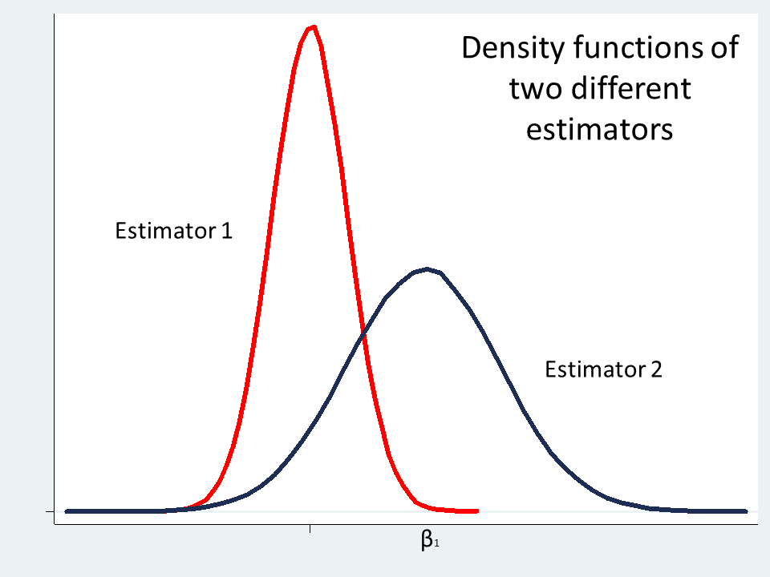

Realisations of Two Estimators

#### Estimator 1

Bias cannot be fixed with more data. Variance can be.

# **Exercise 9:** OLS vs Alternative Estimators

## OLS Minimisation Gives Best Properties

### Two Different Minimisation Criteria

#### OLS Minimises Squared Residuals

$$\min \sum_{i=1}^n \hat{\varepsilon}_i^2$$

- Mean regression
- **BLUE** (Best Linear Unbiased Estimator)
- Closed-form solution

#### LAD Minimises Absolute Residuals

$$\min \sum_{i=1}^n |\hat{\varepsilon}_i|$$

- Median regression
- Robust to outliers
- No closed-form solution

Under AS1-AS6, OLS has smallest variance among unbiased estimators

# **Exercise 10:** Proving $\hat{\beta}_0$ is Unbiased

## Proving Unbiasedness Requires Careful Expectation Algebra

### Each Step Uses Linearity and Independence

#### Given Definitions and Results

1. $y_i = \beta_0 + \beta_1 x_i + e_i$ (Population model)
2. $\hat{\beta}_0 = \bar{y} - \hat{\beta}_1\bar{x}$ (MP3)
3. $\mathbb{E}[\hat{\beta}_1-\beta_1] = 0$ (Given from the question)
4. $\mathbb{E}[e_i] = 0$ (AS4)

#### Intermediate Results

1. Average (1) over $i\in\{1,...,n\}$: $\bar{y} = \beta_0 + \beta_1\bar{x} + \bar{e}$
2. Substract (a) into (2): $\hat{\beta}_0 - \beta_0 = \bar{e} - (\hat{\beta}_1 - \beta_1)\bar{x}$.

#### We Need To Prove

$$\mathbb{E}[\hat{\beta}_0 - \beta_0] = 0$$

## The Unbiasedness Proof

### Starting from the Definition

#### Mathematical Derivation

$$\begin{align}
\mathbb{E}[\hat{\beta}_0 - \beta_0] &= \mathbb{E}[\bar{e} - (\hat{\beta}_1 - \beta_1)\bar{x}] \tag{1} \\
&= \frac{1}{n} \sum_{i=1}^{n} \underbrace{\mathbb{E}[e_{i}]}_{0} - \mathbb{E}[(\hat{\beta}_1-\beta_1)\bar{x}] \tag{2}\\
&= 0 - \underbrace{\mathbb{E}[\hat{\beta}_1-\beta_1]}_{0}\bar{x} \tag{3} \\
&= 0 \tag{4}
\end{align}$$

$\therefore\hat{\beta}_0$ is unbiased $\blacksquare$

#### Explanation of Each Step

1. Substitute Intermediate Result (b).
2. Use linearity of $\mathbb{E}$ and AS4.
3. Holding $\bar{x}$ fixed, and use linearity of $\mathbb{E}$.
4. Use unbiasedness of $\hat{\beta}_1$ (Given Result 3).

# **Exercise 11:** Deriving var($\hat{\beta}_0$)

## The Intercept Variance Formula

### If $\text{var}(\hat{\beta}_0) = \text{var}(\bar{e}) + \text{var}(\hat{\beta}_1\bar{x})$, then $\text{var}(\hat{\beta}_0) = \frac{\sigma^2\sum_{i=1}^n x_i^2}{n\sum_{i=1}^n(x_i - \bar{x})^2}$

#### Assumptions and Previous Derivations

1. The error terms are independent.
2. $\text{var}(e_{i}) = \sigma^2$ See proof
3. $\text{var}(\hat{\beta}_1) = \frac{\sigma^2}{n}\frac{1}{\text{var}(x)}$ (See Exercise 7)

#### Analyse the average error term

$$\begin{align*}
\text{var}(\bar{e}) &= \text{var}\left(\frac{1}{n}\sum_{i=1}^{n}e_{i}\right) \\
&= \frac{1}{n^2}\sum_{i=1}^{n}\text{var}(e_{i}) \\
&= \frac{1}{n^2}\cdot n \cdot \sigma^2 = \frac{\sigma^2}{n}
\end{align*}$$

## The Intercept Variance Formula

### If $\text{var}(\hat{\beta}_0) = \text{var}(\bar{e}) + \text{var}(\hat{\beta}_1\bar{x})$, then $\text{var}(\hat{\beta}_0) = \frac{\sigma^2\sum_{i=1}^n x_i^2}{n\sum_{i=1}^n(x_i - \bar{x})^2}$

#### Wrapping up

1. For the slope estimator, take the $\bar{x}$ as fixed:
   $$\text{var}(\hat{\beta}_1 \bar{x}) = \bar{x}^{2} \cdot \text{var}(\hat{\beta}_1)$$
2. Substitute the Previous Derivation 3 into the above.
3. Substitute both results into the initial equation.
4. Homogenise the expression.
5. Use the identity $\sum_{i=1}^n(x_i - \bar{x})^2 + n\bar{x}^2 = \sum_{i=1}^n x_i^2 \blacksquare$.

Follows similar logic to Exercise 7

# **Exercise 12:** Sample Size and Precision

## Small Samples Generate Extreme Estimates

### US States Education Returns Example

#### Population Model

$\log(\text{wage}_{i}) = \beta_0 + \beta_1 \cdot \text{education}_{i} + e_{i}$

| State | Population | n | $\hat{\beta}_1$ |
| --- | --- | --- | --- |
| **California** | 38,332,521 | 383 | 0.070 |
| **New York** | 19,651,127 | 197 | 0.065 |
| **Florida** | 19,552,860 | 196 | 0.075 |
| **Wyoming** | 582,658 | 6 | **0.200** |
| **North Dakota** | 723,393 | 7 | **0.010** |
| **South Dakota** | 844,877 | 8 | **0.150** |

#### The Pattern

- **Large states** ($n > 100$):
  - **Estimates:** 0.065 - 0.075
  - Clustered around truth
- **Small states** ($n < 10$):
  - **Estimates:** 0.010 - 0.200
  - **Wildly variable**

## Sampling Variance Explains the Pattern

### Not Economics, Just Statistics

$$\text{var}(\hat{\beta}_1) = \frac{\sigma^2}{n \cdot \text{var}(x)}$$

#### Why Small States Differ

- Small $n$ → Large $\text{var}(\hat{\beta}_1)$
- More likely to get extreme estimates
- Pattern is **statistical**, not economic

#### The Truth

- All states likely have $\beta_1 \approx 0.07$
- Education returns similar across US
- Need adequate samples for reliable estimates

Cannot conclude small states have different returns to education

# **Exercise 13:** Prediction Variance Increases with Distance from $\bar{x}$

## Further From the Mean Means Less Reliable Predictions

### Out-of-Sample Prediction Uncertainty

#### Given

- **OLS estimates:** $\hat{\beta}_0$ and $\hat{\beta}_1$
- **New observation:** $x_i^*$ (not in sample)
- **Prediction:** $\hat{y}_i^* = \hat{\beta}_0 + \hat{\beta}_1 x_i^*$
- **MP3:** $\hat{\beta}_0 = \bar{y} - \hat{\beta}_1\bar{x}$

#### We Need To Show

$$(x_i^* - \bar{x})^2 \uparrow \implies \text{var}(\hat{y}_i^*) \uparrow$$

## The Proof Uses MP3 to Isolate the Random Component

### Deriving Prediction Variance

#### Express prediction using MP3

$$\hat{y}_i^* = \hat{\beta}_0 + \hat{\beta}_1 x_i^* = \bar{y} - \hat{\beta}_1\bar{x} + \hat{\beta}_1 x_i^*$$

#### Rearrange to show distance from mean

$$\hat{y}_i^* - \bar{y} = \hat{\beta}_1(x_i^* - \bar{x})$$

#### Take variance

$$\text{var}(\hat{y}_i^* - \bar{y}) = \text{var}[\hat{\beta}_1(x_i^* - \bar{x})]$$

#### Treating $\bar{y}$, $\bar{x}$, $x_i^*$ as constants

$$\text{var}(\hat{y}_i^*) \uparrow = (x_i^* - \bar{x})^2 \uparrow \cdot \text{var}(\hat{\beta}_1)$$

Distance from mean enters quadratically into prediction uncertainty $\blacksquare$

## Mathematical Reasoning in Econometrics

### Five Steps to Valid Proofs

#### The Universal Structure

1. **State** given conditions
2. **Identify** what to prove
3. **Choose** appropriate technique
4. **Execute** justified steps
5. **Conclude** explicitly ($\blacksquare$)

#### Today’s Proof Techniques

- **Sign analysis** (correlation → slope sign)
- **Definition verification** (mechanical vs random)
- **Contradiction** (impossible residual patterns)
- **Optimization** (FOCs for OLS)
- **Algebraic manipulation** ($R^2$ and correlation)

Every step requires justification - intuition guides, mathematics proves

# Next Week

## Multiple Regression

### From Simple to Multiple: Controlling for Confounders

**Key Questions We’ll Answer:**

- What does “controlling for” actually mean?
- How do we interpret coefficients when multiple variables are present?
- When does omitting a variable bias our results?
- Why does R² always increase with more variables?
- Can residual patterns reveal omitted variable bias?
- How do we reduce variance in our estimates?
- Why is minimum variance important?

**Prepare by:** Thinking about what “holding constant” means in practice

# **Appendix:** Further Mathematical Derivations

## Algebraic Identity for Exercise 4

### Proving $\sum x_{i}(y_{i} - \bar{y}) = \sum(x_{i} - \bar{x})(y_{i} - \bar{y})$

#### Expand the RHS

$$\begin{align*}
&\sum_{i=1}^{n}(x_{i} - \bar{x})(y_{i} - \bar{y}) \\
&= \sum_{i=1}^{n} x_{i}(y_{i} - \bar{y}) \\
&- \bar{x}\sum_{i=1}^{n}(y_{i} - \bar{y})
\end{align*}$$

#### Deviations from mean always sum to zero

$$\begin{align*}
&\sum_{i=1}^{n}(y_{i} - \bar{y}) \\
&= \sum_{i=1}^{n} y_{i} - \sum_{i=1}^{n} \bar{y} \\
&= n\underbrace{\frac{1}{n}\sum_{i=1}^{n} y_{i}}_{\bar{y}} - n\bar{y} \\
&= 0
\end{align*}$$

#### Therefore

$$\begin{align*}
&\sum_{i=1}^{n}(x_{i} - \bar{x})(y_{i} - \bar{y}) \\
&= \sum_{i=1}^{n} x_{i}(y_{i} - \bar{y}) - \bar{x} \cdot 0 \\
&= \sum_{i=1}^{n} x_{i}(y_{i} - \bar{y})
\end{align*}$$

Continue with Exercise 4

## Orthogonality of Fitted Values and Residuals

### Why $\text{cov}(\hat{y}, \hat{\varepsilon}) = 0$?

#### Since $\hat{y}_{i} = \hat{\beta}_{0} + \hat{\beta}_{1} x_{i}$

$$\begin{align*}
\sum_{i=1}^{n} \hat{y}_{i}\hat{\varepsilon}_{i} &= \sum_{i=1}^{n} (\hat{\beta}_{0} + \hat{\beta}_{1} x_{i})\hat{\varepsilon}_{i} \\
&= \sum_{i=1}^{n} \hat{\beta}_{0}\hat{\varepsilon}_{i} + \sum_{i=1}^{n} \hat{\beta}_{1} x_{i}\hat{\varepsilon}_{i} \\
&= \hat{\beta}_{0} \underbrace{\sum_{i=1}^{n} \hat{\varepsilon}_{i}}_{MP1} + \hat{\beta}_{1} \underbrace{\sum_{i=1}^{n} x_{i}\hat{\varepsilon}_{i}}_{MP2}\\
&= \hat{\beta}_{0} \cdot 0 + \hat{\beta}_{1} \cdot 0 = 0 \; \text{MP5}
\end{align*}$$

#### Converting to covariance

$$\begin{align*}
\text{cov}(\hat{y}, \hat{\varepsilon}) &= \frac{1}{n}\sum_{i=1}^{n} (\hat{y}_{i} - \bar{\hat{y}})(\hat{\varepsilon}_{i} - \bar{\hat{\varepsilon}}) \\
&= \frac{1}{n}\underbrace{\sum_{i=1}^{n} \hat{y}_{i}\hat{\varepsilon}_{i}}_{MP5} - \bar{\hat{y}} \cdot \frac{1}{n}\underbrace{\sum_{i=1}^{n} \hat{\varepsilon}_{i}}_{MP1} \\
&=0 - \bar{\hat{y}} \cdot 0 = 0
\end{align*}$$

Continue with Exercise 5

## Proving $\text{var}(e_i|x_i) = \sigma^2$ Using Total Variance

### From Conditional to Unconditional Variance

#### The Law of Total Variance States

$$\text{var}(e_i) = \mathbb{E}[\text{var}(e_i|x_i)] + \text{var}[\mathbb{E}[e_i|x_i]]$$

#### By AS4 (Zero conditional mean)

$$\mathbb{E}[e_i|x_i] = 0$$
$$\therefore\text{var}[\mathbb{E}[e_i|x_i]] = \text{var}[0] = 0$$

#### By AS5 (Homoskedasticity)

$$\text{var}(e_i|x_i) = \sigma^2 \text{ for all } x_i$$

#### Substituting into total variance

$$\text{var}(e_i) = \mathbb{E}[\sigma^2] + 0 = \sigma^2$$

Therefore: $\text{var}(e_i|x_i) = \text{var}(e_i) = \sigma^2$ $\blacksquare$

Continue to Exercise 11